# Reconciling hospital and payer price disclosures

A unified schema, a component-aware price adjustment, and a linkage-based confidence model

Bulat Idrisov

July 19, 2026

# 1 Overview

We are given two price disclosures for the same three hospitals and the same three billing codes. One is published by insurers and lists the rates they have negotiated to pay providers. The other is published by hospitals and lists the rates they have agreed to accept. In principle the two describe the same contracted prices, so a rate in one should appear in the other. In practice they use different schemas, identify providers differently, and report prices at different levels of detail.

The goal is a single table at one shared level of observation in which each row carries the hospital’s price, the insurer’s price, and the gap between them, together with an explicit statement of how confident we are in the match.

The analysis proceeds in five moves. We reshape both files onto a shared unit of observation and join them. We put their prices onto a common footing by separating the facility and professional components of a service. We benchmark every price against Medicare so that different services are comparable and can be checked against published national figures. We assess how well the two sources agree using a formal method-comparison approach. And we express match confidence as a probabilistic linkage score rather than a set of hand-set rules.

```r
hpt <- read_csv("hpt_extract_20250213.csv", show_col_types = FALSE)
tic <- read_csv("tic_extract_20250213.csv", show_col_types = FALSE)
c(hospital_rows = nrow(hpt), payer_rows = nrow(tic))
```

```
## hospital_rows    payer_rows
##          2950           222
```

# 2 What one row means in each file

One row is one negotiated price for one service under one arrangement. The hospital file breaks a service out by plan and care setting, so a single service appears on several rows. The payer file breaks the same service out by network, billing class, and place of service, so it too has several rows per service. The two files therefore sit at different levels of observation and cannot be compared row to row until we reshape both onto a common grain. The shared grain we adopt is:

> hospital (tax id) x code family x code x insurer

# 3 Identifying the same hospital

The payer file has no hospital name and no state. It identifies a provider only by a nine digit tax identification number (the EIN) and a list of provider identifiers (NPIs). The hospital file carries the same tax id, embedded in the source file name, though formatted differently across records. The tax id is therefore the only reliable link between the two files, so we normalize it to nine digits and join on it.

```r
# Tax id: keep the first nine digits, dropping punctuation and any suffix.
clean_ein <- function(x) str_sub(str_remove_all(x, "\\D"), 1, 9)

# Billing code: drop punctuation and any leading "MSDRG" label.
clean_code <- function(x) str_remove(str_remove_all(x, "[^0-9A-Za-z]"), "^(?i)MSDRG")

# Code family: inpatient bundles (DRG) behave differently from single services (CPT).
code_family <- function(x) case_when(
  str_detect(str_to_upper(x), "DRG")       ~ "DRG",
  str_detect(str_to_upper(x), "CPT|HCPCS") ~ "CPT",
  TRUE                                     ~ str_to_upper(x)
)

# Insurer names: reduce the many published spellings to a single label.
payer_lookup <- c(
  unitedhealthcare = "UHC", uhc = "UHC", united = "UHC",
  aetna = "AETNA",
  `cigna-corporation` = "CIGNA", cigna = "CIGNA"
)
clean_payer <- function(x) {
  key <- str_to_lower(str_trim(x))
  unname(coalesce(payer_lookup[key], str_to_upper(key)))
}

hospital_names <- c(
  `131740114` = "Montefiore Medical Center",
  `131624096` = "The Mount Sinai Hospital",
  `133971298` = "NYU Langone"
)
```

Some hospital rows describe government plans (Medicare Advantage, Medicaid, and similar). The payer file here contains national commercial products only, so we keep commercial hospital rows to avoid comparing a commercial rate against a government rate.

```r
noncommercial <- c("medicare", "medicaid", "chip", "harp",
                   "essential", "child health", "managed long")
is_commercial <- function(plan) {
  !str_detect(str_to_lower(replace_na(plan, "")), str_c(noncommercial, collapse = "|"))
}
```

```r
big3 <- c("AETNA", "CIGNA", "UHC")

hpt_norm <- hpt %>%
  mutate(
    ein        = clean_ein(word(source_file_name, 1, sep = "_")),
    code       = clean_code(raw_code),
    family     = code_family(code_type),
    payer      = clean_payer(payer_name),
    rate       = as.numeric(standard_charge_negotiated_dollar),
    commercial = is_commercial(plan_name)
  )

tic_norm <- tic %>%
  mutate(
    ein    = clean_ein(ein),
    code   = clean_code(code),
    family = code_family(code_type),
    payer  = clean_payer(payer),
    rate   = as.numeric(rate),
    cms    = as.numeric(cms_baseline_rate)
  )
```

# 4 Deterministic join

Joining the normalized files on tax id, code, and insurer already succeeds for most combinations. This section shows where the clean join works and where it does not, before we address price alignment.

```r
key <- c("ein", "family", "code", "payer")

hpt_keys <- hpt_norm %>%
  filter(payer %in% big3, commercial, !is.na(rate)) %>%
  distinct(across(all_of(key)))
tic_keys <- tic_norm %>%
  filter(!is.na(rate)) %>%
  distinct(across(all_of(key)))

full_join(mutate(hpt_keys, in_hospital = TRUE),
          mutate(tic_keys, in_payer = TRUE), by = key) %>%
  mutate(across(c(in_hospital, in_payer), ~replace_na(., FALSE)),
         status = case_when(
           in_hospital & in_payer ~ "both",
           in_hospital            ~ "hospital_only",
           TRUE                   ~ "payer_only")) %>%
  count(status)
```

| status | n |
| --- | --- |
| both | 20 |
| hospital_only | 5 |
| payer_only | 5 |

The combinations that fail to join are informative. Inpatient bundle codes (DRG) often appear in the hospital file but not the payer file, because insurers do not always publish a bundled inpatient rate in the same form. This mirrors published findings that payer disclosures are least complete for hospital inpatient services (AJMC 2025). A few hospital rows use a local, hospital specific code that has no counterpart in the payer file. These are structural gaps, not join errors.

# 5 Aligning prices: assigning facility charges to a total

A clean join tells us two rows describe the same service, but it does not make their prices comparable, because a service is billed in two parts:

- a facility component, which is what the hospital charges for its rooms, equipment, and staff, and
- a professional component, which is what the treating physician charges.

The full price of a service is the sum of the two. The two files do not report the same part. The payer file labels every row as professional or institutional (facility), so it always shows both parts. The hospital file reports a single unlabeled number, and different hospitals report different parts: some a facility scale number, some a professional scale number. Comparing a facility only number against a professional only number produces differences of ten times or more that are reporting artifacts, not real disagreements. We remove this artifact as follows.

To assign a partial, facility only figure up to a total, we apply the approach for scaling facility spending to a total developed by our team at the Institute for Health Metrics and Evaluation published in JAMA of which I am a co-author (Dieleman et al. 2025). The method learns the ratio between a component and the full amount from records that contain both, then applies that ratio to records that carry only one component. Here we adapt it from health spending estimation to the reconciliation of price disclosures.

**Step 1. Learn the component ratios from the file that reports both parts.** For each code we take the median facility rate and the median professional rate from the payer file and define the full price as their sum. From these we form two scaling ratios: facility to full and professional to full.

```r
component_ratio <- tic_norm %>%
  filter(!is.na(rate)) %>%
  group_by(family, code) %>%
  summarise(
    n_facility     = sum(billing_class == "institutional"),
    n_professional = sum(billing_class == "professional"),
    facility_med   = median(rate[billing_class == "institutional"]),
    prof_med       = median(rate[billing_class == "professional"]),
    .groups = "drop"
  ) %>%
  mutate(
    full         = rowSums(cbind(facility_med, prof_med), na.rm = TRUE),
    fac_to_full  = if_else(n_facility     > 0, full / facility_med, 1),
    prof_to_full = if_else(n_professional > 0, full / prof_med,     1)
  )
component_ratio
```

| family | code | n_facility | n_professional | facility_med | prof_med | full | fac_to_full | prof_to_full |
| --- | --- | --- | --- | --- | --- | --- | --- | --- |
| CPT | 43239 | 21 | 82 | 5845 | 502.045 | 6347.045 | 1.085893 | 12.64238 |
| CPT | 99283 | 5 | 95 | 2117 | 77.290 | 2194.290 | 1.036509 | 28.39035 |
| DRG | 872 | 19 | 0 | 17966 | NA | 17966.000 | 1.000000 | 1.00000 |

The professional component is a small fraction of the facility component, so for these codes the full price is close to the facility price and the facility to full ratio is near one. The inpatient bundle code has no professional rows, because the bundle is itself the facility payment and the physician bills separately, so its ratio is one and no adjustment is made. This is the smallest sample branch of a general rule: with many observations we would fit a robust linear model of the ratio over time and source; with few we take the median, as here; with none we leave the rate unadjusted. On this sample the median branch is the one that runs.

**Step 2. Detect which part the hospital reported, then scale it to full price.**

```r
log_dist <- function(a, b) if_else(a > 0 & b > 0, abs(log(a / b)), Inf)

hospital_side <- hpt_norm %>%
  filter(payer %in% big3, commercial, !is.na(rate)) %>%
  group_by(across(all_of(key))) %>%
  summarise(hospital_rate = median(rate), .groups = "drop") %>%
  left_join(component_ratio, by = c("family", "code")) %>%
  mutate(
    reported_part = if_else(
      log_dist(hospital_rate, facility_med) <= coalesce(log_dist(hospital_rate, prof_med), Inf),
      "facility", "professional"),
    hospital_full = if_else(reported_part == "facility",
                            hospital_rate * fac_to_full,
                            hospital_rate * prof_to_full)
  )

payer_side <- tic_norm %>%
  filter(!is.na(rate)) %>%
  group_by(across(all_of(key)), billing_class) %>%
  summarise(rate = median(rate), .groups = "drop") %>%
  pivot_wider(names_from = billing_class, values_from = rate) %>%
  left_join(dplyr::select(component_ratio, family, code, facility_med, prof_med),
            by = c("family", "code")) %>%
  mutate(
    facility     = if_else(is.na(institutional) & !is.na(professional),
                           professional * facility_med / prof_med, institutional),
    professional = if_else(is.na(professional) & !is.na(institutional),
                           institutional * prof_med / facility_med, professional),
    payer_full   = rowSums(cbind(facility, professional), na.rm = TRUE)
  )
```

# 6 Benchmarking to Medicare

Prices for different services are not comparable in dollars: a colonoscopy and an emergency visit sit on different scales. The standard solution in the price transparency literature is to express each commercial price as a multiple of what Medicare pays for the same service (the approach used by the RAND Hospital Price Transparency Study). The payer file already carries the Medicare baseline for each rate in `cms_baseline_rate`, drawn from the physician fee schedule for professional services, the outpatient system for outpatient facility services, and the inpatient system for inpatient bundles. We compute the ratio of each rate to its Medicare baseline.

```r
payer_ratio <- tic_norm %>%
  filter(!is.na(rate), !is.na(cms), cms > 0) %>%
  mutate(
    component = case_when(
      family == "DRG"                    ~ "Inpatient facility",
      billing_class == "institutional"   ~ "Outpatient facility",
      TRUE                               ~ "Professional"),
    ratio = rate / cms
  )

payer_ratio %>%
  group_by(component) %>%
  summarise(n = n(), median_x_medicare = round(median(ratio), 2), .groups = "drop")
```

| component | n | median_x_medicare |
| --- | --- | --- |
| Inpatient facility | 19 | 2.63 |
| Outpatient facility | 26 | 6.64 |
| Professional | 176 | 1.16 |

These figures can be read against published national benchmarks. RAND reports commercial prices averaging about 255 percent of Medicare for inpatient facility services, 289 percent for outpatient facility services, and 188 percent for professional services. Our inpatient facility ratio is close to that benchmark. The professional ratio is lower and the outpatient facility ratio is higher, which is consistent with these being specific procedures at large academic medical centers in a high price market rather than a national average.

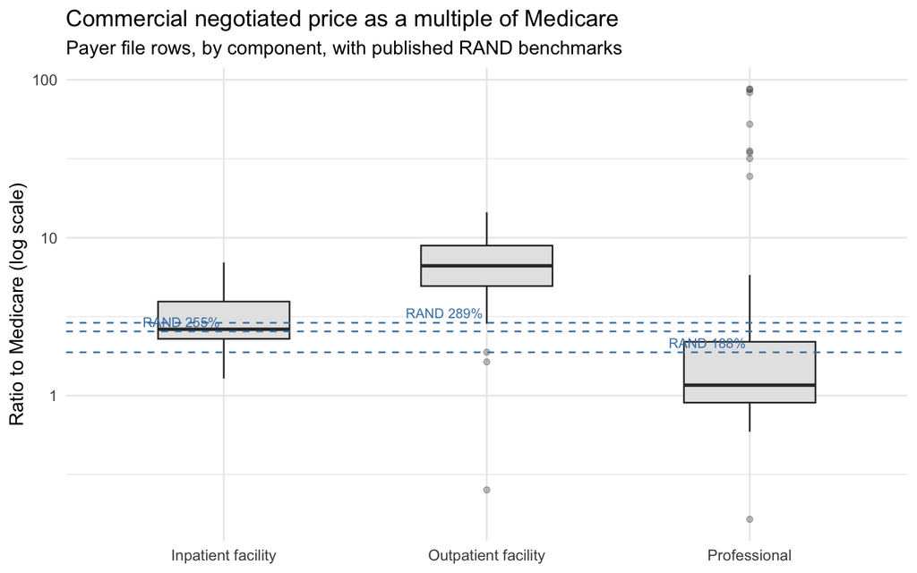

```r
benchmarks <- tibble(
  component = c("Inpatient facility", "Outpatient facility", "Professional"),
  rand      = c(2.55, 2.89, 1.88)
)

ggplot(payer_ratio, aes(component, ratio)) +
  geom_boxplot(outlier.alpha = 0.3, width = 0.5, fill = "grey90") +
  geom_hline(data = benchmarks, aes(yintercept = rand),
             linetype = "dashed", colour = "steelblue") +
  geom_text(data = benchmarks, aes(x = component, y = rand,
            label = paste0("RAND ", round(rand * 100), "%")),
            vjust = -0.5, hjust = 1.05, size = 3, colour = "steelblue") +
  scale_y_log10() +
  labs(title = "Commercial negotiated price as a multiple of Medicare",
       subtitle = "Payer file rows, by component, with published RAND benchmarks",
       x = NULL, y = "Ratio to Medicare (log scale)")
```

# 7 Agreement between the two sources

Rather than only report a dollar gap, we treat the two files as two independent methods of measuring the same underlying negotiated price and ask how well they agree. The standard tool for this in health research is the method of Bland and Altman: plot the difference between the two measurements against their mean, and report the average difference (the bias) and the limits within which most differences fall. Because prices are strongly right skewed, we work on the log scale, so a difference of logs is the log of the ratio of the two prices.

```r
matched <- inner_join(
    dplyr::select(hospital_side, all_of(key), hospital_full, reported_part,
                  n_facility, n_professional),
    dplyr::select(payer_side, all_of(key), payer_full),
    by = key) %>%
  filter(hospital_full > 0, payer_full > 0) %>%
  mutate(
    hospital = recode(ein, !!!hospital_names),
    log_diff = log(hospital_full) - log(payer_full),
    log_mean = (log(hospital_full) + log(payer_full)) / 2
  )

ba <- matched %>%
  summarise(bias = mean(log_diff), sd = sd(log_diff)) %>%
  mutate(lower = bias - 1.96 * sd, upper = bias + 1.96 * sd)

tibble(
  statistic = c("Geometric mean ratio (hospital / payer)",
                "Lower limit of agreement", "Upper limit of agreement",
                "Pearson r (log prices)", "Lin's concordance (log prices)"),
  value = c(
    round(exp(ba$bias), 2), round(exp(ba$lower), 2), round(exp(ba$upper), 2),
    round(cor(log(matched$payer_full), log(matched$hospital_full)), 2),
    { x <- log(matched$payer_full); y <- log(matched$hospital_full)
      round(2 * cov(x, y) / (var(x) + var(y) + (mean(x) - mean(y))^2), 2) }
  )
)
```

| statistic | value |
| --- | --- |
| Geometric mean ratio (hospital / payer) | 1.30 |
| Lower limit of agreement | 0.38 |
| Upper limit of agreement | 4.43 |
| Pearson r (log prices) | 0.79 |
| Lin's concordance (log prices) | 0.76 |

On this sample the two sources agree moderately well. The correlation of log prices is about 0.8 and Lin’s concordance is about 0.76. The hospital derived full price is on average about 30 percent higher than the payer derived full price, and most ratios fall between roughly 0.4 and 4. The wide limits reflect the small sample and the handful of combinations where the component detection is uncertain.

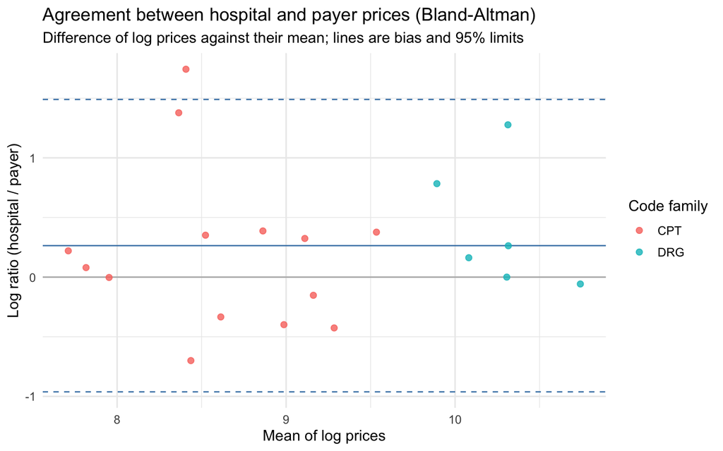

```r
ggplot(matched, aes(log_mean, log_diff)) +
  geom_hline(yintercept = 0, colour = "grey70") +
  geom_hline(yintercept = ba$bias, colour = "steelblue") +
  geom_hline(yintercept = c(ba$lower, ba$upper),
             linetype = "dashed", colour = "steelblue") +
  geom_point(aes(colour = family), size = 2, alpha = 0.8) +
  labs(title = "Agreement between hospital and payer prices (Bland-Altman)",
       subtitle = "Difference of log prices against their mean; lines are bias and 95% limits",
       x = "Mean of log prices", y = "Log ratio (hospital / payer)", colour = "Code family")
```

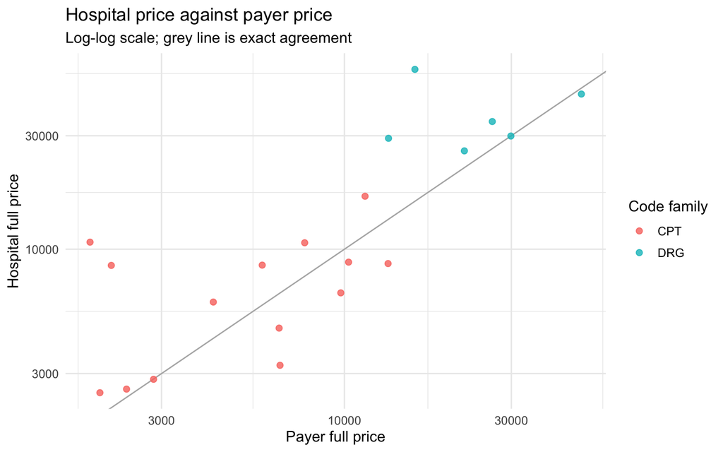

```r
ggplot(matched, aes(payer_full, hospital_full, colour = family)) +
  geom_abline(slope = 1, intercept = 0, colour = "grey70") +
  geom_point(size = 2, alpha = 0.8) +
  scale_x_log10() + scale_y_log10() +
  labs(title = "Hospital price against payer price",
       subtitle = "Log-log scale; grey line is exact agreement",
       x = "Payer full price", y = "Hospital full price", colour = "Code family")
```

# 8 Confidence as probabilistic record linkage

The remaining question is how much to trust each match. Rather than set arbitrary cutoffs, we frame it as a record linkage problem in the classical way (Fellegi and Sunter, 1969). Each field that can agree or disagree is given a weight equal to the log ratio of two probabilities: the chance the field agrees when the pair is a true match, and the chance it agrees by coincidence when it is not. Agreement adds weight, disagreement subtracts it, and the weights sum to a single score. Two thresholds split the score into a confident match, a confident non-match, and a middle band reserved for human review.

Here the tax id, code, and insurer are the join key, so they always agree and the entity match itself is essentially certain. The open question is therefore price corroboration: whether the two reported prices are consistent. We score that against the agreement distribution from the previous section, reporting for each pair how typical its price gap is for a true match. This price consistency runs from 0 to 1. It is near 1 when the gap sits at the center of the distribution and falls below about 0.05 once the gap crosses the limits of agreement, which is the point at which we stop calling a pair a match.

```r
# Given a candidate pair (same tax id, code, insurer), the open question is
# whether the two prices corroborate. We measure that against the Bland-Altman
# fit: how typical is this pair's price gap for a true match. A pair inside the
# limits of agreement is a match, outside is a non-match, and inpatient bundles
# (no professional part to model) are sent to review.
linked <- matched %>%
  mutate(
    z                 = (log_diff - ba$bias) / ba$sd,
    price_consistency = round(2 * pnorm(-abs(z)), 2),
    price_agrees      = log_diff >= ba$lower & log_diff <= ba$upper,
    decision = case_when(
      coalesce(n_professional, 0) == 0 ~ "review (no professional part to model)",
      price_agrees                     ~ "match",
      TRUE                             ~ "non-match")
  )

linked %>% count(decision)
```

| decision | n |
| --- | --- |
| match | 13 |
| non-match | 1 |
| review (no professional part to model) | 6 |

This gives a transparent, tunable rule. The threshold at the limits of agreement can be raised or lowered to trade precision against recall, and pairs that fall outside become an explicit, sized queue for manual review, which is how a production matcher of this kind is operated. At national scale the same framework would carry estimated agreement weights on additional fields, such as the provider identifier, plan, and modifiers, so the confidence would reflect more than price alone.

# 9 The unified output

We now assemble the deliverable: one row per hospital, code, and insurer, carrying both raw prices, both full price estimates, the ratio to Medicare where available, the price ratio between the two sources, the price consistency, and the decision. Combinations present on only one side are retained and marked, so the table also documents the coverage gaps. Column definitions are in the codebook below.

```r
medicare_by_cell <- payer_ratio %>%
  group_by(across(all_of(key))) %>%
  summarise(payer_x_medicare = round(median(ratio), 2), .groups = "drop")

unified <- full_join(
    dplyr::select(hospital_side, all_of(key), hospital_rate, reported_part, hospital_full),
    dplyr::select(payer_side,    all_of(key), payer_full),
    by = key) %>%
  left_join(dplyr::select(linked, all_of(key), price_consistency, decision), by = key) %>%
  left_join(medicare_by_cell, by = key) %>%
  mutate(
    hospital = recode(ein, !!!hospital_names),
    # Status reflects which file the raw rate came from, not whether it could be scaled.
    status   = case_when(
      !is.na(hospital_rate) & !is.na(payer_full) ~ "both",
      !is.na(hospital_rate)                      ~ "hospital_only",
      TRUE                                       ~ "payer_only"),
    price_ratio = round(hospital_full / payer_full, 2),
    decision    = coalesce(decision, "unmatched")
  ) %>%
  arrange(hospital, payer, family, code) %>%
  dplyr::select(hospital, payer, family, code, status,
                hospital_rate, reported_part, hospital_full, payer_full,
                payer_x_medicare, price_ratio, price_consistency, decision)

write_csv(unified, "unified_output.csv")
unified
```

| hospital | payer | family | code | status | hospital_rate | reported_part | hospital_full | payer_full | payer_x_medicare | price_ratio | price_consistency | decision |
| --- | --- | --- | --- | --- | --- | --- | --- | --- | --- | --- | --- | --- |
| Montefiore Medical Center | AETNA | CPT | 43239 | both | 1320.76 | professional | 16697.553 | 11453.630 | 2.02 | 1.46 | 0.86 | match |
| Montefiore Medical Center | AETNA | CPT | 99283 | both | 377.13 | professional | 10706.852 | 1873.763 | 0.86 | 5.71 | 0.02 | non-match |
| Montefiore Medical Center | AETNA | DRG | 872 | hospital_only | 48629.30 | facility | 48629.300 | NA | NA | NA | NA | unmatched |
| Montefiore Medical Center | CIGNA | CPT | 43239 | both | 841.81 | professional | 10642.484 | 7697.504 | 1.45 | 1.38 | 0.92 | match |
| Montefiore Medical Center | CIGNA | CPT | 99283 | both | 301.08 | professional | 8547.766 | 2155.260 | 3.22 | 3.97 | 0.07 | match |
| Montefiore Medical Center | CIGNA | DRG | 872 | both | 44909.82 | facility | 44909.820 | 47574.460 | 6.97 | 0.94 | 0.61 | review (no professional part to model) |
| Montefiore Medical Center | UHC | CPT | 43239 | both | 688.30 | professional | 8701.752 | 13325.325 | 4.68 | 0.65 | 0.27 | match |
| Montefiore Medical Center | UHC | CPT | 99283 | both | 211.16 | professional | 5994.906 | 4218.522 | 1.92 | 1.42 | 0.89 | match |
| Montefiore Medical Center | UHC | DRG | 872 | both | 57020.41 | facility | 57020.410 | 15902.000 | 2.33 | 3.59 | 0.11 | review (no professional part to model) |
| NYU Langone | AETNA | CPT | 43239 | both | 8124.66 | facility | 8822.512 | 10275.355 | 1.55 | 0.86 | 0.51 | match |

[output cut: 20 more lines]

## 9.1 Codebook

| Column | Meaning |
| --- | --- |
| `hospital` | Hospital name, recovered from the tax id (the payer file carries no name). |
| `payer` | Insurer, normalized to a single label (AETNA, CIGNA, UHC). |
| `family` | Code type: CPT (a single service), DRG (a bundled inpatient stay), LOCAL (a hospital’s own internal code). |
| `code` | The billing code (43239 endoscopy with biopsy, 99283 emergency visit, 872 sepsis inpatient stay). |
| `status` | Which file the raw rate came from: `both`, `hospital_only`, or `payer_only`. |
| `hospital_rate` | The hospital file’s raw negotiated rate (median across its commercial plans), before any adjustment. |
| `reported_part` | Which component the hospital rate is inferred to be: `facility` or `professional`. `NA` when not determinable. |
| `hospital_full` | The hospital rate scaled to a full-encounter estimate (facility plus professional). `NA` when no scaling ratio exists. |
| `payer_full` | The insurer’s full-encounter price, its facility and professional parts summed. |
| `payer_x_medicare` | The insurer’s price as a multiple of Medicare (2.02 means 202 percent of Medicare). |
| `price_ratio` | `hospital_full` divided by `payer_full` (1.46 means the hospital side is 1.46 times the payer side). `NA` unless matched on both sides. |
| `price_consistency` | How typical the price gap is for a true match, from 0 to 1. Near 1 is central; below about 0.05 is outside the limits of agreement. |
| `decision` | `match`, `non-match`, `review (no professional part to model)`, or `unmatched`. |

# 10 Completeness

Finally we quantify coverage, since a large part of the practical value is knowing what is missing. We report, for each insurer and code family, the share of the three hospitals for which each file carries a usable rate.

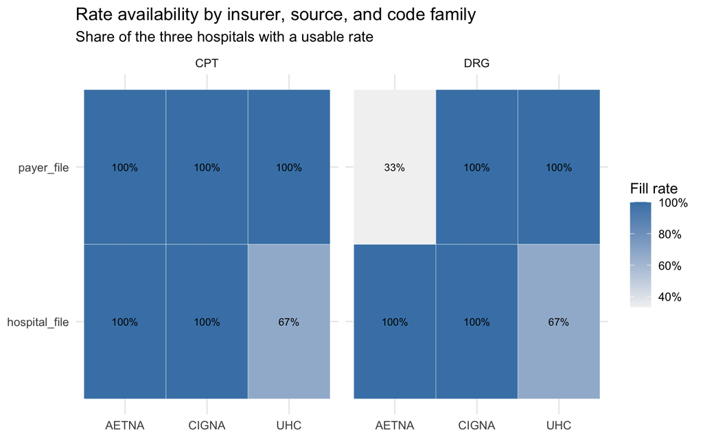

```r
grid <- expand_grid(ein = names(hospital_names), payer = big3,
                    family = c("CPT", "DRG"))

hpt_present <- hpt_keys %>% distinct(ein, payer, family) %>% mutate(hospital = TRUE)
tic_present <- tic_keys %>% distinct(ein, payer, family) %>% mutate(payer_has = TRUE)

fill <- grid %>%
  left_join(hpt_present, by = c("ein", "payer", "family")) %>%
  left_join(tic_present, by = c("ein", "payer", "family")) %>%
  mutate(across(c(hospital, payer_has), ~replace_na(., FALSE))) %>%
  group_by(payer, family) %>%
  summarise(hospital_file = mean(hospital), payer_file = mean(payer_has),
            .groups = "drop") %>%
  pivot_longer(c(hospital_file, payer_file), names_to = "source", values_to = "fill_rate")

ggplot(fill, aes(payer, source, fill = fill_rate)) +
  geom_tile(colour = "white") +
  geom_text(aes(label = scales::percent(fill_rate, accuracy = 1)), size = 3) +
  facet_wrap(~ family) +
  scale_fill_gradient(low = "grey95", high = "steelblue", labels = scales::percent) +
  labs(title = "Rate availability by insurer, source, and code family",
       subtitle = "Share of the three hospitals with a usable rate",
       x = NULL, y = NULL, fill = "Fill rate")
```

The inpatient (DRG) row is the sparsest on the payer side, which is the same pattern documented nationally and the reason inpatient bundle matching is the hardest part of this problem.

# 11 Limitations and how this scales

The sample is small and deliberately clean, so several decisions that do not bite here would need real work at national volume.

*Charge against payment.* We compare the hospital’s negotiated rate against the insurer’s negotiated rate, so both are payment side figures and no further adjustment is needed. If we fell back to a hospital’s gross charge, we would first convert that charge to an expected payment, since charges and payments differ.

*Plan and network alignment.* We filtered to commercial plans with a keyword rule. A production version would map each hospital plan name to the specific insurer network, and treat plan type as an input to the linkage score rather than part of the join key, so a near match on a slightly different product is retained but marked less certain.

*Provider identity.* We matched at the tax id level. A tax id can cover more than one facility, so at scale we would use the provider identifier (NPI) list in the payer file to confirm the rate applies to the specific hospital campus.

*Local codes.* A few hospital rows use a local code with no standard counterpart and would need a crosswalk before matching.

*Component detection.* Deciding which part a hospital reported by nearest scale is a heuristic and is fragile for small professional scale numbers. A better signal is the hospital’s own care setting and billing indicators.

*Testing and release.* At volume we would add checks on fill rates by field, on the plausibility of each scaling ratio and each ratio to Medicare, and on the distribution of gaps by code and insurer, and release the matcher behind these checks so a regression in match quality is caught before publication.

# 12 References

- Bland JM, Altman DG. Statistical methods for assessing agreement between two methods of clinical measurement. Lancet, 1986.
- Cooper Z, Craig SV, Gaynor M, Van Reenen J. The Price Ain’t Right? Hospital Prices and Health Spending on the Privately Insured. Quarterly Journal of Economics, 2019.
- Dieleman JL, Beauchamp M, Crosby SW,..Idrisov B… et al. Tracking US Health Care Spending by Health Condition and County. JAMA, 2025;333(12):1051-1061. doi:10.1001/jama.2024.26790.
- Fellegi IP, Sunter AB. A Theory for Record Linkage. Journal of the American Statistical Association, 1969.
- RAND Corporation. Hospital Price Transparency Study (Round 5). 2024.
- Assessing the Completeness of Payer Transparency in Coverage Data. American Journal of Managed Care, 2025.